# PA1_template

# Loading and preprocessing the data

```r
df <- read.csv("activity.csv")
```

# What is the mean total number of steps taken per day?

## 1. Calculate the total number of steps taken per day

```r
tsteps <- aggregate(steps ~ date, df, sum, na.rm = TRUE)

tsteps
```

```
##          date steps
## 1  10/10/2012  9900
## 2  10/11/2012 10304
## 3  10/12/2012 17382
## 4  10/13/2012 12426
## 5  10/14/2012 15098
## 6  10/15/2012 10139
## 7  10/16/2012 15084
## 8  10/17/2012 13452
## 9  10/18/2012 10056
## 10 10/19/2012 11829
## 11  10/2/2012   126
## 12 10/20/2012 10395
## 13 10/21/2012  8821
## 14 10/22/2012 13460
```

[output cut: 39 more lines]

## 2. Make a histogram of the total number of steps taken each day

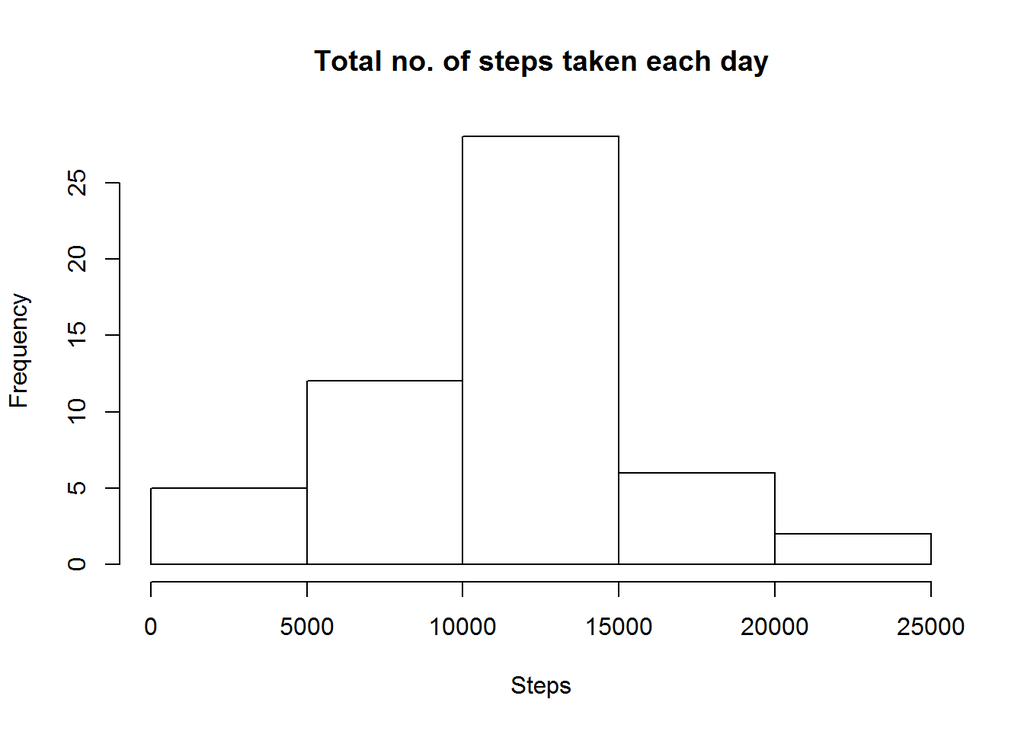

```r
hist(tsteps$steps, xlab = "Steps", main = "Total no. of steps taken each day")
```

## 3. Calculate and report the mean and median of the total number of steps per day

```r
Mean_steps <- mean(tsteps$steps)
Mean_steps
```

```
## [1] 10766.19
```

```r
Median_steps <- median(tsteps$steps)
Median_steps
```

```
## [1] 10765
```

# What is the average daily activity pattern?

## 1. Make a time series plot(i.e, type = “l) of the 5-minute interval (x-axis) and the average number of steps taken, averaged across all days (y-axis)

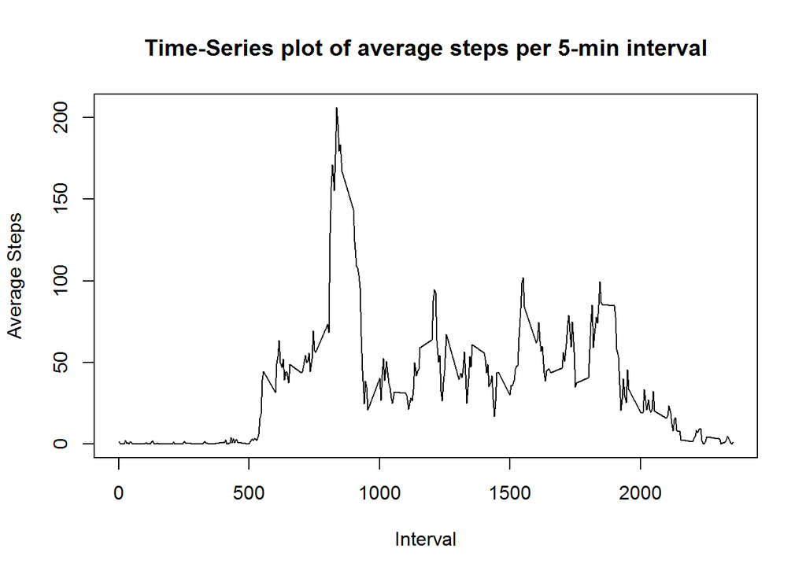

```r
dsteps <- aggregate(steps ~ interval, df, mean)

plot(x = dsteps$interval, y = dsteps$steps,  type = 'l', xlab = "Interval", ylab = "Average Steps",
     main = "Time-Series plot of average steps per 5-min interval")
```

## 2. Which 5-minute interval, on average across all the days in the dataset, contains the maximum no. of steps?

```r
x <- dsteps[dsteps$steps == max(dsteps$steps),]

int <- x$interval

int
```

```
## [1] 835
```

# Imputing Missing values

## 1. Calculate and report the total number of missing values in the dataset (i.e., the total number of rows with NAs)

```r
sum(is.na(df$date))
```

```
## [1] 0
```

```r
sum(is.na(df$interval))
```

```
## [1] 0
```

```r
sum(is.na(df$steps))
```

```
## [1] 2304
```

## 2. Devise a strategy for filling in all of missing values in the dataset.

### Replace NAs with 0.

## 3. Create a new dataset that is equal to the original dataset but with the missing data filled in.

The strategy is to substitute NAs with 0s.

```r
df1 <- df

df1$steps <- replace(df1$steps, is.na(df1$steps), 0)
```

## 4. Make a histogram of the total number of steps taken per day. Do these values differ from the estimates in the first part of the assignment? What is the impact of imputing missing data on the estimates of the total daily number of steps?

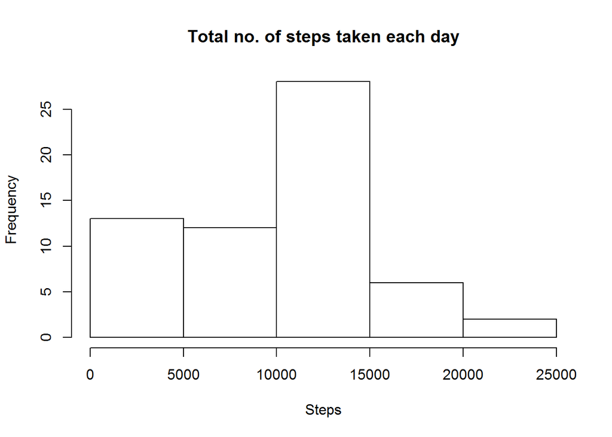

```r
tsteps1 <- aggregate(steps ~ date, df1, sum)

hist(tsteps1$steps, xlab = "Steps", main = "Total no. of steps taken each day")
```

```r
Mean_steps1 <- mean(tsteps1$steps) #9354.23

Median_steps1 <- median(tsteps1$steps) #10395
```

Imputing missing data reduces the mean and median values.

# Are there differences in activity patterns between weekdays and weekends?

## 1. Create a new factor variable in the dataset with two levels - “weekday” and “weekend” indicating whether a given date is a weekday or weekend day.

Yes, there are differences between the actvity patterns of weekdays and weekends.

```r
d_col <- as.Date(df1$date, format = "%m/%d/%Y")

w_col <- weekdays(d_col)

day <- character(length(w_col))

for (i in 1:length(w_col))
{
  if (w_col[i] == "Saturday" || w_col[i] == "Sunday")
  {day[i] <- "weekend"}

  else
  {day[i] <- "weekday"}

}

df2 <- cbind(df1, day)
```

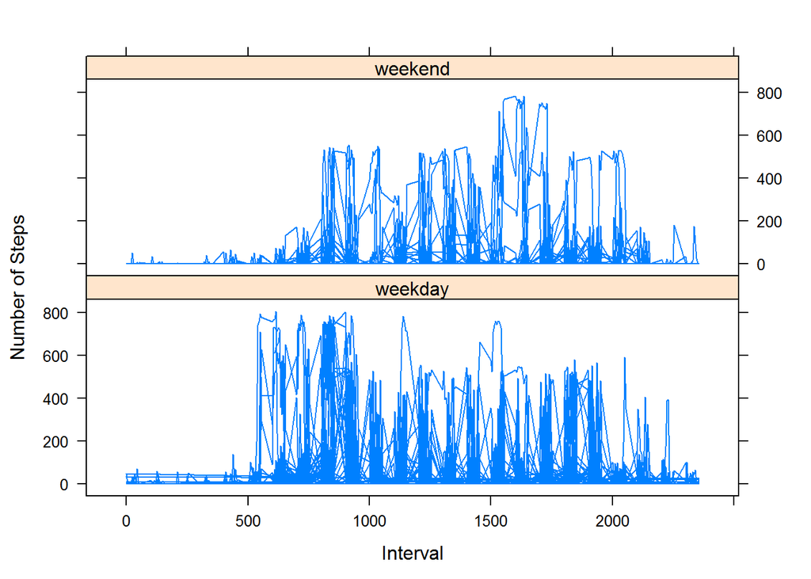

```r
library(lattice)

df3 <- split(df2, f = as.factor(df2$day) )

df3_weekday <- data.frame(df3$weekday, stringsAsFactors = TRUE)

df3_weekend <- data.frame(df3$weekend, stringsAsFactors = TRUE)

df3_weekday_steps <- aggregate(steps ~ interval, df3_weekday, mean)

df3_weekend_steps <- aggregate(steps ~ interval, df3_weekend, mean)

final_df <- rbind(df3_weekday, df3_weekend)

xyplot(steps~interval|factor(day), final_df,
       type='l',layout=c(1,2),
       xlab='Interval',ylab='Number of Steps')
```